# Gadiel_Shepherd_Project2_full_code_notebook

### Post-Pruning

- Let's try improve the model using post-pruning.
- This method lets the tree to fully grow, and then subtrees are pruned and replaced by leaf nodes (using cost complexity pruning).

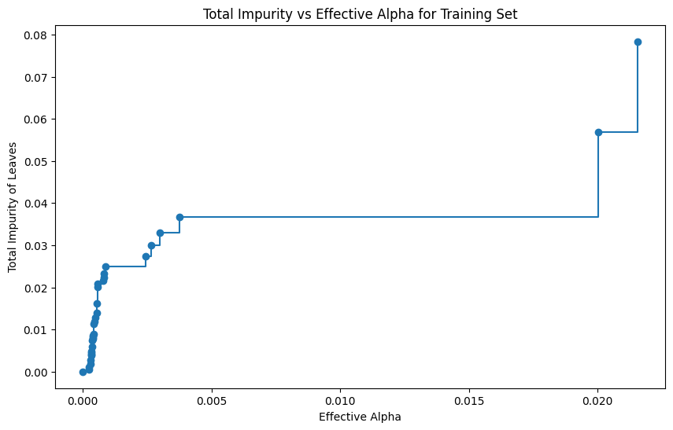

```python
# Creating an instance of the decision tree model
clf=DecisionTreeClassifier(random_state=RS)

# Compute the cost complexity pruning path for the model using training data
path=clf.cost_complexity_pruning_path(X_train,y_train)

# Extracting the array of effective alphas from pruning path
ccp_alphas=abs(path.ccp_alphas)

# Extracting the array of total impurities at each alpha along the pruning path
impurities=path.impurities

# Plotting the total impurities versus effective alphas, excluding the last value (which is the alpha that corresponds with a tree with one node)
fig, ax=plt.subplots(figsize=(10,6))
ax.plot(ccp_alphas[:-1], impurities[:-1], marker='o', drawstyle="steps-post")
ax.set_xlabel("Effective Alpha")
ax.set_ylabel("Total Impurity of Leaves")
ax.set_title("Total Impurity vs Effective Alpha for Training Set")
plt.show()
```

### Observations:

- As the alpha increases (less model complexity), the impurity increases (which is to be expected).
- There is a sharp increase in impurity as the alpha increases from 0 to approximately 0.001.
- The impurity increases gradually as alpha approaches approximately 0.004.
- We will find the optimal alpha next (which will likely be in the range 0.000-0.003) by training a decision tree using the effective alphas.

```python
# Initialize an empty list to store the decision tree classifiers
clfs=[]

# Iterate over each ccp_alpha value extracted from the cost complexity pruning path
for ccp_alpha in ccp_alphas:
  # Create an instance of the decision tree classifier
  clf=DecisionTreeClassifier(random_state=RS,ccp_alpha=ccp_alpha)
  # Fit the classifier to the training data
  clf.fit(X_train,y_train)
  # Append the classifier to the list
  clfs.append(clf)

# Remove the last classifier and corresponding ccp_alpha value from the lists (as this corresponds to the tree with one node)
clfs=clfs[:-1]
ccp_alphas=ccp_alphas[:-1]

# Initialize an empty list to store F1 scores for each classifier on the test set
test_f1_scores=[]

# Iterate over each classifier in the list
for clf in clfs:
  # Make predictions on the test set using the classifier
  pred_test=clf.predict(X_test)
  # Calculate the F1 score for the predictions
  f1_test=f1_score(y_test,pred_test)
  # Append the F1 score to the list
  test_f1_scores.append(f1_test)

# Creating the model where we get the highest test F1 score
index_best_clf=np.argmax(test_f1_scores)

# Selecting the decision tree model corresponding to the highest test score
dtree3=clfs[index_best_clf]
print(dtree3)
```

```
DecisionTreeClassifier(ccp_alpha=np.float64(0.0008702884311333967),
                       random_state=42)
```

### Observations:

- The optimal effective alpha= 0.00087.

```python
# Evaluating the post-pruned model on the test set vs the train test
dtree3_train_perf=model_performance_classification(dtree3,X_train,y_train)
dtree3_test_perf=model_performance_classification(dtree3,X_test,y_test)

print("Evaluation Metrics of Train Set \n", dtree3_train_perf)
print('-'*100)
print("Evaluation Metrics of Test Set \n", dtree3_test_perf)
```

```
Evaluation Metrics of Train Set
    Accuracy    Recall  Precision        F1
0   0.98475  0.885417   0.952381  0.917679
----------------------------------------------------------------------------------------------------
Evaluation Metrics of Test Set
    Accuracy    Recall  Precision        F1
0     0.991  0.958333   0.948454  0.953368
```

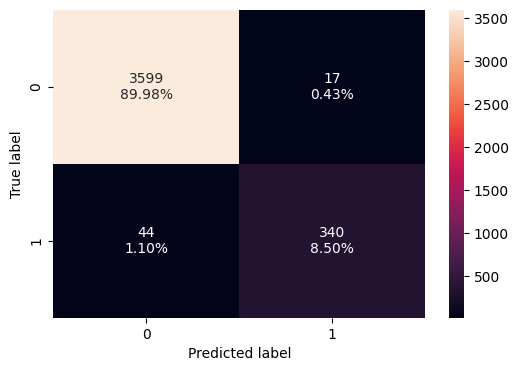

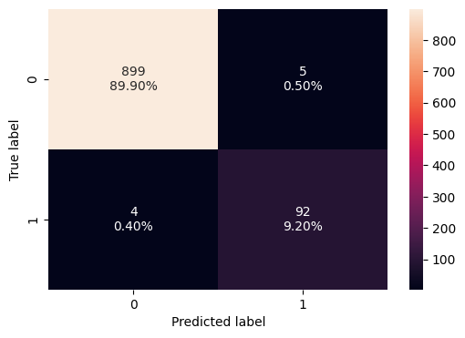

```
None None
```

```python
# Plotting the confusion matrix for train and test sets from the post-pruned model
print(plot_confusion_matrix(dtree3,X_train,y_train),plot_confusion_matrix(dtree3,X_test,y_test))
```

### Observations:

- As expected, the evaluation metrics of the post-pruned model on the train set is not perfect.
  - This is due to the complexity reduction of the model which prevents the final model from fully fitting to the train set. This prevents overfitting.
- We have successfully improved the evaluation metrics of the post-pruned model on the test set when compared to the default model.
  - There is an improvement on all evaluation metrics, most notably on Precision (0.875 vs 0.948) and F1 Score (0.91 vs 0.953).
  - The post-pruned model has made less mistakes (18 vs 9(5 Type I + 4 Type II)).
- Surprisingly, the post-pruned evaluation metrics of the test set are better than the metrics for the train set (with the exception of Precision).
  - This means that not only the model generalizes well, it performs even better on unseen data.
    - This should be approached with caution as other factors could be influencing this difference and should be further investigated.

### Visualizing the post-pruned tree

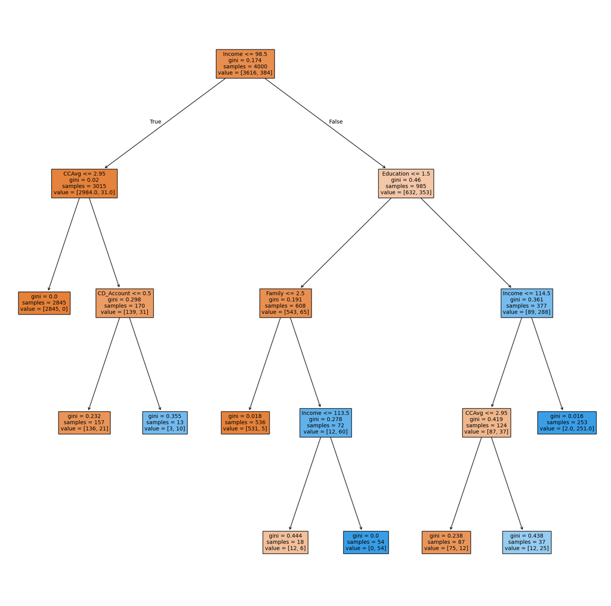

```
Tree depth: 4
Number of nodes: 17
Number of leaf nodes: 9
```

```python
# List of feature names in X_train
feature_names=list(X_train.columns)

# Plotting the decision tree
plt.figure(figsize=(20,20))
out=tree.plot_tree(dtree3,
                   feature_names=feature_names,
                   filled=True,
                   fontsize=10)
plt.show()

# Printing the the depth, number of nodes, and number of leaf nodes of the Decision Tree
depth_t3 = dtree3.get_depth()
n_nodes_t3 = dtree3.tree_.node_count
n_leaves_t3 = dtree3.get_n_leaves()

print(f"Tree depth: {depth_t3}")
print(f"Number of nodes: {n_nodes_t3}")
print(f"Number of leaf nodes: {n_leaves_t3}")
```

### Observations:

- The post-pruned tree is much simpler than the default tree (and even simpler and easier to interpret than the pre-pruned tree).
  - The tree has a depth of 4, 17 overall nodes and 9 leaf nodes.
- The decision rule of the root node uses the Income attribute where the splitting criteria is Income <= 98.5.
  - If a customer meets the criteria, the splitting criteria of the child node is CCAvg <= 2.95.
  - If a customer does not meet the criteria, the splitting criteria of the child node is Education <= 1.5.
  - Subsequent nodes use attributes such as Income, CCAvg, CD_Account and Family.

## Model Performance Comparison and Final Model Selection

- Let's compare the evaluation metrics of the test and train sets for the default, pre-pruned and post-pruned models.

```python
# Performance comparison
models_train_comp_df=pd.concat(
    [
        dtree1_train_perf.T,
        dtree1_test_perf.T,
        dtree2_train_perf.T,
        dtree2_test_perf.T,
        dtree3_train_perf.T,
        dtree3_test_perf.T
    ],
    axis=1
)
models_train_comp_df.columns=["Default(Train)","Default(Test)","Pre-Pruned(Train)","Pre-Pruned(Test)","Post-Pruned(Train)","Post-Pruned(Test)"]
print("Performance Comparison")
models_train_comp_df
```

```
Performance Comparison
```

|  | Default(Train) | Default(Test) | Pre-Pruned(Train) | Pre-Pruned(Test) | Post-Pruned(Train) | Post-Pruned(Test) |
| --- | --- | --- | --- | --- | --- | --- |
| Accuracy | 1.0 | 0.982000 | 0.988250 | 0.987000 | 0.984750 | 0.991000 |
| Recall | 1.0 | 0.947917 | 0.908854 | 0.958333 | 0.885417 | 0.958333 |
| Precision | 1.0 | 0.875000 | 0.966759 | 0.910891 | 0.952381 | 0.948454 |
| F1 | 1.0 | 0.910000 | 0.936913 | 0.934010 | 0.917679 | 0.953368 |

- Let's compare the model complexity of the default, pre-pruned and post-pruned models.

```python
# Compiling model parameters into dataframes
df_dtree1_param=pd.DataFrame(
      {"Depth":depth_t1,"Number of Nodes":n_nodes_t1,"Number of Leaf Nodes":n_leaves_t1},
      index=[0]
  )
df_dtree2_param=pd.DataFrame(
      {"Depth":depth_t2,"Number of Nodes":n_nodes_t2,"Number of Leaf Nodes":n_leaves_t2},
      index=[0]
  )
df_dtree3_param=pd.DataFrame(
      {"Depth":depth_t3,"Number of Nodes":n_nodes_t3,"Number of Leaf Nodes":n_leaves_t3},
      index=[0]
  )

# Compiling model parameters into a single dataframe for comparison
df_param_comp_df=pd.concat(
    [
        df_dtree1_param.T,
        df_dtree2_param.T,
        df_dtree3_param.T
    ],
    axis=1
  )
df_param_comp_df.columns=["Default","Pre-Pruned","Post-Pruned"]
print("Model Parameters Comparison")
df_param_comp_df
```

```
Model Parameters Comparison
```

|  | Default | Pre-Pruned | Post-Pruned |
| --- | --- | --- | --- |
| Depth | 12 | 6 | 4 |
| Number of Nodes | 127 | 49 | 17 |
| Number of Leaf Nodes | 64 | 25 | 9 |

### Model Comparison:

- Default model:
  - Performance metrics on the train set are perfect (which is expected). This leads to overfitting.
  - Performance metrics on the test set are relatively decent, but it is clear that the model is overfitted as the performance metrics are worse than the train set.
  - It is the most complex tree.
- Pre-pruned model:
  - The performance metrics on the test set have improved compared to the test set from the default model.
    - Therefore the pre-pruned model performs better and is more robust compared to the default model.
  - The performance metrics in the train and test sets are similar (especially Accuracy and F1 Score).
    - This means that the pre-pruned model has good generalization ability.
  - It is important to note that the test set performed worst on Precision, which in the context of loan approval, is not a good thing as the bank should avoid wrongly approving bad loans.
  - The tree is less complex than the default tree.
- Post-pruned model:
  - The performance on the test set have the highest metrics across all parameters among the 3 models.
  - Surprsingly, the performance metrics on the test set are better than the train set (except for Precision).
    - Therefore not only did the model genralize well, it performed better on unseen data.
      - This should be investigated further.
  - It is the least complex tree.

### Model Selection:

- It is clear that the best model is the Post-pruned Decision Tree:
1. Performance
- The post-pruned model performed the best on the test set compared to the rest of the models on Accuracy, Recall, Precision and F1 Score.
2. Generalization ability
- The post-pruned model generalized the best on the test set, even performing better than the train set.
3. Complexity and computational cost
- While the post-pruning method has a higher computational cost than the pre-pruning method, it lead to the least complex tree (even less complex than the pre-pruned tree).
- This is because the post-pruning method is more targeted and data-driven than the pre-pruning method. It selectively prunes away subtrees that do not contain much predictive power. This leaves behind a much simpler, yet more powerful predictive model.

### Feature Importance of the Post-pruned model

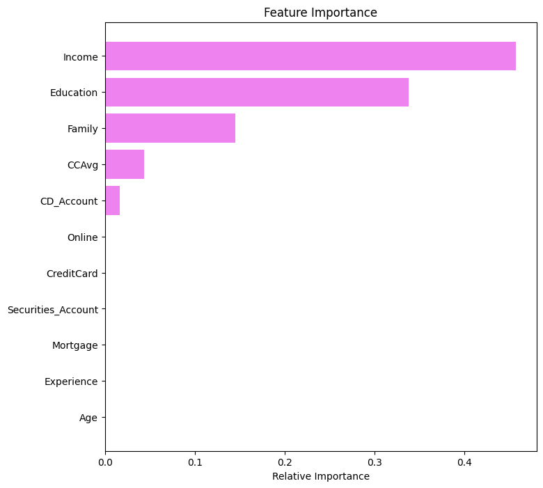

```python
# Importance of features in the tree building (of the post-pruned model)
importances=dtree3.feature_importances_
indices=np.argsort(importances)

# Plotting the feature importance
plt.figure(figsize=(8,8))
plt.title("Feature Importance")
plt.barh(range(len(indices)),importances[indices],color="violet",align="center")
plt.yticks(range(len(indices)),[feature_names[i] for i in indices])
plt.xlabel("Relative Importance")
plt.show()
```

### Observations:

- The most important feature in this model is Income, followed by Education, Family, CCAvg and CD_Account.
  - This is not surprsing as Income is the attribute used in the root node for the initial split.
- Other features such as Online, CreditCard, Securities_Account, Mortgage, Experience and Age are not important.
  - This is due to the model not taking these features into account in any splitting criteria.
  - These features will likely have some importance in the default and pre-pruned models.

## Actionable Insights and Business Recommendations

### Actionable Insights:

- Key Drivers for Personal Loan Purchase:
  - The most significant attributes influencing a customer's likelihood of purchasing a personal loan are Income, Education, Family size, Average Credit Card spending (CCAvg), and whether they have a Certificate of Deposit (CD) account. Other features like Age, Experience, Mortgage, Securities Account, Online banking usage, and Credit Card usage with other banks appear to have little to no impact on this decision according to the model.
- Income as a Primary Indicator:
  - Income is the most crucial factor in determining if a customer will take a personal loan. Customers with higher incomes are more likely to be interested.
- Education Level Matters:
  - Customers with higher education levels (Graduate and Advanced/Professional) are more inclined to take personal loans compared to those with an Undergraduate education.
- Family Size and Spending Habits:
  - Both family size and average credit card spending play a role in predicting loan uptake, suggesting that customers with larger families and those who spend more on credit cards might have different financial needs or behaviors that make them more receptive to personal loans.
- CD Account Holders are Potential Targets:
  - Customers who already have a CD account are more likely to be open to personal loan offers. This might indicate a segment of customers who are already actively engaged with the bank's financial products.

### Business Recommendations:

- Targeted Marketing Campaigns:
  - Focus marketing efforts for personal loans on liability customers who fit the profile of those most likely to purchase based on the key attributes identified:
    - Customers with higher incomes.
    - Customers with Graduate or Advanced/Professional education levels.
    - Customers with specific family sizes and credit card spending patterns (further analysis could be done on specific ranges of these attributes).
    - Customers who hold CD accounts with the bank.
- Tailored Loan Offers:
  - Develop different personal loan offers or marketing messages that resonate with the characteristics of the target segments. For example, highlight the benefits of personal loans for higher-income individuals or those with larger families.
- Cross-selling to CD Account Holders:
  - Actively promote personal loan options to customers who have CD accounts, as the model suggests they are more receptive to such offers. This can be done through online banking platforms, email campaigns, or even in-branch interactions.
- Review of Current Strategies:
  - Re-evaluate existing personal loan marketing strategies to ensure they are aligned with the insights from the model. If current campaigns heavily rely on factors that the model shows are not important (like Age or Experience), consider shifting focus to the more influential attributes.

By implementing these recommendations, the bank can significantly improve the success rate of their personal loan campaigns by targeting the most promising segments of their liability customer base.